# Risk Factor Analysis

## Outcome Variable

**Outcome Variable:** ever_co

## Predictor Variables

**Intervention Variable:** meducyrs

**Adjustment Set:**

- arm
- W_mage
- feducyrs
- hhwealth_quart
- W_mhtcm
- W_mwtkg
- W_mbmi
- W_gagebrth
- W_birthwt
- W_birthlen
- single
- impsan
- delta_W_mage
- delta_feducyrs
- delta_hhwealth_quart
- delta_W_mhtcm
- delta_W_mwtkg
- delta_W_mbmi
- delta_W_gagebrth
- delta_W_birthwt
- delta_W_birthlen
- delta_single
- delta_impsan

## Stratifying Variables

The analysis was stratified on these variable(s):

- agecat
- studyid
- country

## Data Summary

| agecat | studyid | country | meducyrs | ever_co | n_cell | n |
| --- | --- | --- | --- | --- | --- | --- |
| 0-24 months | CMC-V-BCS-2002 | INDIA | High | 0 | 132 | 373 |
| 0-24 months | CMC-V-BCS-2002 | INDIA | High | 1 | 26 | 373 |
| 0-24 months | CMC-V-BCS-2002 | INDIA | Low | 0 | 77 | 373 |
| 0-24 months | CMC-V-BCS-2002 | INDIA | Low | 1 | 29 | 373 |
| 0-24 months | CMC-V-BCS-2002 | INDIA | Medium | 0 | 78 | 373 |
| 0-24 months | CMC-V-BCS-2002 | INDIA | Medium | 1 | 31 | 373 |
| 0-24 months | COHORTS | GUATEMALA | High | 0 | 253 | 1322 |
| 0-24 months | COHORTS | GUATEMALA | High | 1 | 27 | 1322 |
| 0-24 months | COHORTS | GUATEMALA | Low | 0 | 555 | 1322 |
| 0-24 months | COHORTS | GUATEMALA | Low | 1 | 72 | 1322 |
| 0-24 months | COHORTS | GUATEMALA | Medium | 0 | 366 | 1322 |
| 0-24 months | COHORTS | GUATEMALA | Medium | 1 | 49 | 1322 |
| 0-24 months | COHORTS | INDIA | High | 0 | 776 | 5841 |
| 0-24 months | COHORTS | INDIA | High | 1 | 16 | 5841 |
| 0-24 months | COHORTS | INDIA | Low | 0 | 1623 | 5841 |
| 0-24 months | COHORTS | INDIA | Low | 1 | 327 | 5841 |
| 0-24 months | COHORTS | INDIA | Medium | 0 | 2896 | 5841 |
| 0-24 months | COHORTS | INDIA | Medium | 1 | 203 | 5841 |
| 0-24 months | COHORTS | PHILIPPINES | High | 0 | 1036 | 3045 |
| 0-24 months | COHORTS | PHILIPPINES | High | 1 | 132 | 3045 |
| 0-24 months | COHORTS | PHILIPPINES | Low | 0 | 670 | 3045 |
| 0-24 months | COHORTS | PHILIPPINES | Low | 1 | 231 | 3045 |
| 0-24 months | COHORTS | PHILIPPINES | Medium | 0 | 779 | 3045 |
| 0-24 months | COHORTS | PHILIPPINES | Medium | 1 | 197 | 3045 |
| 0-24 months | EE | PAKISTAN | High | 0 | 12 | 376 |
| 0-24 months | EE | PAKISTAN | High | 1 | 3 | 376 |
| 0-24 months | EE | PAKISTAN | Low | 0 | 175 | 376 |
| 0-24 months | EE | PAKISTAN | Low | 1 | 153 | 376 |
| 0-24 months | EE | PAKISTAN | Medium | 0 | 22 | 376 |
| 0-24 months | EE | PAKISTAN | Medium | 1 | 11 | 376 |

[output cut: 438 more lines]

The following strata were considered:

- agecat: 0-24 months, studyid: CMC-V-BCS-2002, country: INDIA
- agecat: 0-24 months, studyid: COHORTS, country: GUATEMALA
- agecat: 0-24 months, studyid: COHORTS, country: INDIA
- agecat: 0-24 months, studyid: COHORTS, country: PHILIPPINES
- agecat: 0-24 months, studyid: EE, country: PAKISTAN
- agecat: 0-24 months, studyid: GMS-Nepal, country: NEPAL
- agecat: 0-24 months, studyid: Guatemala BSC, country: GUATEMALA
- agecat: 0-24 months, studyid: IRC, country: INDIA
- agecat: 0-24 months, studyid: JiVitA-3, country: BANGLADESH
- agecat: 0-24 months, studyid: JiVitA-4, country: BANGLADESH
- agecat: 0-24 months, studyid: LCNI-5, country: MALAWI
- agecat: 0-24 months, studyid: MAL-ED, country: BANGLADESH
- agecat: 0-24 months, studyid: MAL-ED, country: BRAZIL
- agecat: 0-24 months, studyid: MAL-ED, country: INDIA
- agecat: 0-24 months, studyid: MAL-ED, country: NEPAL
- agecat: 0-24 months, studyid: MAL-ED, country: PERU
- agecat: 0-24 months, studyid: MAL-ED, country: SOUTH AFRICA
- agecat: 0-24 months, studyid: MAL-ED, country: TANZANIA, UNITED REPUBLIC OF
- agecat: 0-24 months, studyid: NIH-Birth, country: BANGLADESH
- agecat: 0-24 months, studyid: NIH-Crypto, country: BANGLADESH
- agecat: 0-24 months, studyid: PROBIT, country: BELARUS
- agecat: 0-24 months, studyid: PROVIDE, country: BANGLADESH
- agecat: 0-24 months, studyid: SAS-CompFeed, country: INDIA
- agecat: 0-24 months, studyid: SAS-FoodSuppl, country: INDIA
- agecat: 0-24 months, studyid: TanzaniaChild2, country: TANZANIA, UNITED REPUBLIC OF
- agecat: 0-24 months, studyid: ZVITAMBO, country: ZIMBABWE
- agecat: 0-6 months, studyid: CMC-V-BCS-2002, country: INDIA
- agecat: 0-6 months, studyid: COHORTS, country: GUATEMALA
- agecat: 0-6 months, studyid: COHORTS, country: INDIA
- agecat: 0-6 months, studyid: COHORTS, country: PHILIPPINES
- agecat: 0-6 months, studyid: EE, country: PAKISTAN
- agecat: 0-6 months, studyid: GMS-Nepal, country: NEPAL
- agecat: 0-6 months, studyid: Guatemala BSC, country: GUATEMALA
- agecat: 0-6 months, studyid: IRC, country: INDIA
- agecat: 0-6 months, studyid: JiVitA-3, country: BANGLADESH
- agecat: 0-6 months, studyid: JiVitA-4, country: BANGLADESH
- agecat: 0-6 months, studyid: LCNI-5, country: MALAWI
- agecat: 0-6 months, studyid: MAL-ED, country: BANGLADESH
- agecat: 0-6 months, studyid: MAL-ED, country: BRAZIL
- agecat: 0-6 months, studyid: MAL-ED, country: INDIA
- agecat: 0-6 months, studyid: MAL-ED, country: NEPAL
- agecat: 0-6 months, studyid: MAL-ED, country: PERU
- agecat: 0-6 months, studyid: MAL-ED, country: SOUTH AFRICA
- agecat: 0-6 months, studyid: MAL-ED, country: TANZANIA, UNITED REPUBLIC OF
- agecat: 0-6 months, studyid: NIH-Birth, country: BANGLADESH
- agecat: 0-6 months, studyid: NIH-Crypto, country: BANGLADESH
- agecat: 0-6 months, studyid: PROBIT, country: BELARUS
- agecat: 0-6 months, studyid: PROVIDE, country: BANGLADESH
- agecat: 0-6 months, studyid: SAS-CompFeed, country: INDIA
- agecat: 0-6 months, studyid: SAS-FoodSuppl, country: INDIA
- agecat: 0-6 months, studyid: TanzaniaChild2, country: TANZANIA, UNITED REPUBLIC OF
- agecat: 0-6 months, studyid: ZVITAMBO, country: ZIMBABWE
- agecat: 6-24 months, studyid: CMC-V-BCS-2002, country: INDIA
- agecat: 6-24 months, studyid: COHORTS, country: GUATEMALA
- agecat: 6-24 months, studyid: COHORTS, country: INDIA
- agecat: 6-24 months, studyid: COHORTS, country: PHILIPPINES
- agecat: 6-24 months, studyid: EE, country: PAKISTAN
- agecat: 6-24 months, studyid: GMS-Nepal, country: NEPAL
- agecat: 6-24 months, studyid: Guatemala BSC, country: GUATEMALA
- agecat: 6-24 months, studyid: IRC, country: INDIA
- agecat: 6-24 months, studyid: JiVitA-3, country: BANGLADESH
- agecat: 6-24 months, studyid: JiVitA-4, country: BANGLADESH
- agecat: 6-24 months, studyid: LCNI-5, country: MALAWI
- agecat: 6-24 months, studyid: MAL-ED, country: BANGLADESH
- agecat: 6-24 months, studyid: MAL-ED, country: BRAZIL
- agecat: 6-24 months, studyid: MAL-ED, country: INDIA
- agecat: 6-24 months, studyid: MAL-ED, country: NEPAL
- agecat: 6-24 months, studyid: MAL-ED, country: PERU
- agecat: 6-24 months, studyid: MAL-ED, country: SOUTH AFRICA
- agecat: 6-24 months, studyid: MAL-ED, country: TANZANIA, UNITED REPUBLIC OF
- agecat: 6-24 months, studyid: NIH-Birth, country: BANGLADESH
- agecat: 6-24 months, studyid: NIH-Crypto, country: BANGLADESH
- agecat: 6-24 months, studyid: PROBIT, country: BELARUS
- agecat: 6-24 months, studyid: PROVIDE, country: BANGLADESH
- agecat: 6-24 months, studyid: SAS-CompFeed, country: INDIA
- agecat: 6-24 months, studyid: SAS-FoodSuppl, country: INDIA
- agecat: 6-24 months, studyid: TanzaniaChild2, country: TANZANIA, UNITED REPUBLIC OF
- agecat: 6-24 months, studyid: ZVITAMBO, country: ZIMBABWE

### Dropped Strata

Some strata were dropped due to rare outcomes:

- agecat: 0-24 months, studyid: EE, country: PAKISTAN
- agecat: 0-24 months, studyid: Guatemala BSC, country: GUATEMALA
- agecat: 0-24 months, studyid: MAL-ED, country: BRAZIL
- agecat: 0-24 months, studyid: MAL-ED, country: NEPAL
- agecat: 0-24 months, studyid: MAL-ED, country: PERU
- agecat: 0-24 months, studyid: MAL-ED, country: SOUTH AFRICA
- agecat: 0-24 months, studyid: MAL-ED, country: TANZANIA, UNITED REPUBLIC OF
- agecat: 0-24 months, studyid: PROBIT, country: BELARUS
- agecat: 0-6 months, studyid: COHORTS, country: GUATEMALA
- agecat: 0-6 months, studyid: EE, country: PAKISTAN
- agecat: 0-6 months, studyid: GMS-Nepal, country: NEPAL
- agecat: 0-6 months, studyid: Guatemala BSC, country: GUATEMALA
- agecat: 0-6 months, studyid: LCNI-5, country: MALAWI
- agecat: 0-6 months, studyid: MAL-ED, country: BANGLADESH
- agecat: 0-6 months, studyid: MAL-ED, country: BRAZIL
- agecat: 0-6 months, studyid: MAL-ED, country: INDIA
- agecat: 0-6 months, studyid: MAL-ED, country: NEPAL
- agecat: 0-6 months, studyid: MAL-ED, country: PERU
- agecat: 0-6 months, studyid: MAL-ED, country: SOUTH AFRICA
- agecat: 0-6 months, studyid: MAL-ED, country: TANZANIA, UNITED REPUBLIC OF
- agecat: 0-6 months, studyid: NIH-Crypto, country: BANGLADESH
- agecat: 0-6 months, studyid: PROBIT, country: BELARUS
- agecat: 0-6 months, studyid: SAS-FoodSuppl, country: INDIA
- agecat: 0-6 months, studyid: TanzaniaChild2, country: TANZANIA, UNITED REPUBLIC OF
- agecat: 6-24 months, studyid: EE, country: PAKISTAN
- agecat: 6-24 months, studyid: Guatemala BSC, country: GUATEMALA
- agecat: 6-24 months, studyid: MAL-ED, country: BRAZIL
- agecat: 6-24 months, studyid: MAL-ED, country: NEPAL
- agecat: 6-24 months, studyid: MAL-ED, country: PERU
- agecat: 6-24 months, studyid: MAL-ED, country: SOUTH AFRICA
- agecat: 6-24 months, studyid: MAL-ED, country: TANZANIA, UNITED REPUBLIC OF
- agecat: 6-24 months, studyid: PROBIT, country: BELARUS

## Methods Detail

We’re interested in the causal parameters $E[Y_a]$ for all values of $a \in \mathcal{A}$. These parameters represent the mean outcome if, possibly contrary to fact, we intervened to set all units to have $A=a$. Under the randomization and positivity assumptions, these are identified by the statistical parameters $\psi_a=E_W[E_{Y|A,W}(Y|A=a,W)]$. In addition, we’re interested in the mean of $Y$, $E[Y]$ under no intervention (the observed mean). We will estimate these parameters by using SuperLearner to fit the relevant likelihood factors – $E_{Y|A,W}(Y|A=a,W)$ and $p(A=a|W)$, and then updating our likelihood fit using a joint TMLE.

For unadjusted analyses ($W=\{\}$), initial likelihoods were estimated using Lrnr_glm to estimate the simple $E(Y|A)$ and Lrnr_mean to estimate $p(A)$. For adjusted analyses, a small library containing Lrnr_glmnet, Lrnr_xgboost, and Lrnr_mean was used.

Having estimated these parameters, we will then use the delta method to estimate relative risks and attributable risks relative to a prespecified baseline level of $A$.

# Results Detail

## Results Plots

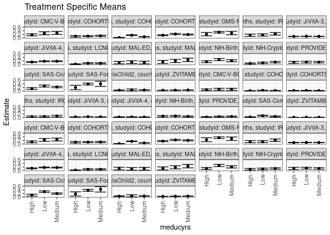

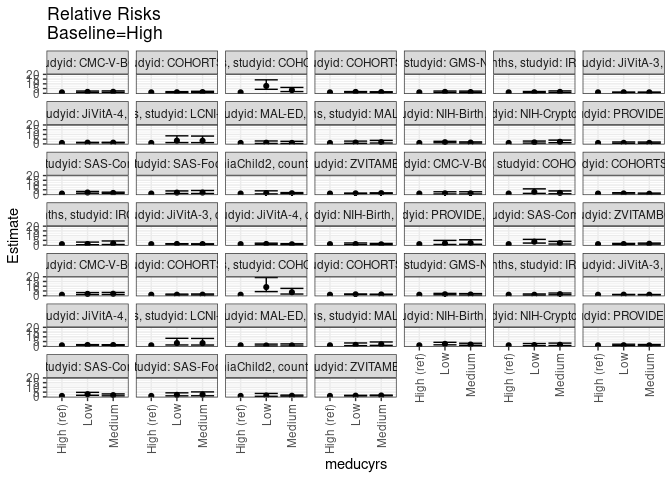

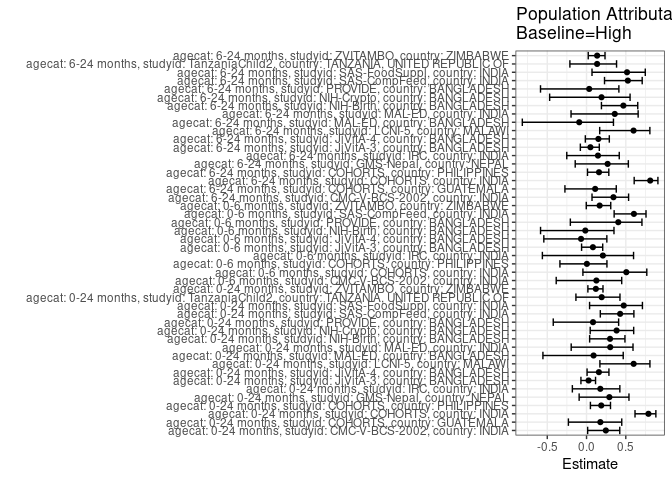

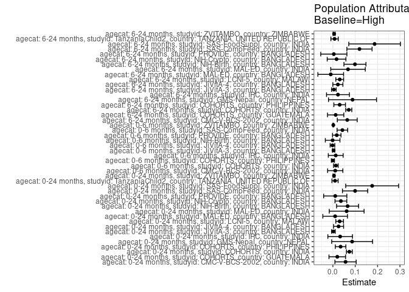

## Results Table

### Parameter: TSM

| agecat | studyid | country | intervention_level | baseline_level | estimate | ci_lower | ci_upper |
| --- | --- | --- | --- | --- | --- | --- | --- |
| 0-24 months | CMC-V-BCS-2002 | INDIA | High | NA | 0.1738441 | 0.1165900 | 0.2310981 |
| 0-24 months | CMC-V-BCS-2002 | INDIA | Low | NA | 0.2622176 | 0.1763945 | 0.3480408 |
| 0-24 months | CMC-V-BCS-2002 | INDIA | Medium | NA | 0.2812446 | 0.1957789 | 0.3667103 |
| 0-24 months | COHORTS | GUATEMALA | High | NA | 0.0922414 | 0.0526568 | 0.1318261 |
| 0-24 months | COHORTS | GUATEMALA | Low | NA | 0.1009214 | 0.0778324 | 0.1240104 |
| 0-24 months | COHORTS | GUATEMALA | Medium | NA | 0.1170014 | 0.0846835 | 0.1493192 |
| 0-24 months | COHORTS | INDIA | High | NA | 0.0197768 | 0.0079537 | 0.0316000 |
| 0-24 months | COHORTS | INDIA | Low | NA | 0.1535237 | 0.1368949 | 0.1701525 |
| 0-24 months | COHORTS | INDIA | Medium | NA | 0.0662968 | 0.0574427 | 0.0751509 |
| 0-24 months | COHORTS | PHILIPPINES | High | NA | 0.1494561 | 0.1236417 | 0.1752704 |
| 0-24 months | COHORTS | PHILIPPINES | Low | NA | 0.2181111 | 0.1852589 | 0.2509634 |
| 0-24 months | COHORTS | PHILIPPINES | Medium | NA | 0.1910615 | 0.1620431 | 0.2200799 |
| 0-24 months | GMS-Nepal | NEPAL | High | NA | 0.2097061 | 0.1153439 | 0.3040684 |
| 0-24 months | GMS-Nepal | NEPAL | Low | NA | 0.3168224 | 0.2749858 | 0.3586590 |
| 0-24 months | GMS-Nepal | NEPAL | Medium | NA | 0.2733106 | 0.1802299 | 0.3663914 |
| 0-24 months | IRC | INDIA | High | NA | 0.1528082 | 0.0890090 | 0.2166073 |
| 0-24 months | IRC | INDIA | Low | NA | 0.1666899 | 0.1055778 | 0.2278020 |
| 0-24 months | IRC | INDIA | Medium | NA | 0.2308157 | 0.1604503 | 0.3011810 |
| 0-24 months | JiVitA-3 | BANGLADESH | High | NA | 0.0864835 | 0.0772855 | 0.0956815 |
| 0-24 months | JiVitA-3 | BANGLADESH | Low | NA | 0.0928406 | 0.0853369 | 0.1003444 |
| 0-24 months | JiVitA-3 | BANGLADESH | Medium | NA | 0.0886449 | 0.0802705 | 0.0970193 |
| 0-24 months | JiVitA-4 | BANGLADESH | High | NA | 0.1361982 | 0.1115807 | 0.1608157 |
| 0-24 months | JiVitA-4 | BANGLADESH | Low | NA | 0.1786140 | 0.1573872 | 0.1998408 |
| 0-24 months | JiVitA-4 | BANGLADESH | Medium | NA | 0.1795098 | 0.1572640 | 0.2017557 |
| 0-24 months | LCNI-5 | MALAWI | High | NA | 0.0201342 | 0.0041770 | 0.0360915 |
| 0-24 months | LCNI-5 | MALAWI | Low | NA | 0.0689655 | 0.0382050 | 0.0997260 |
| 0-24 months | LCNI-5 | MALAWI | Medium | NA | 0.0666667 | 0.0360317 | 0.0973017 |
| 0-24 months | MAL-ED | BANGLADESH | High | NA | 0.1025641 | 0.0350768 | 0.1700514 |
| 0-24 months | MAL-ED | BANGLADESH | Low | NA | 0.1285714 | 0.0499739 | 0.2071690 |
| 0-24 months | MAL-ED | BANGLADESH | Medium | NA | 0.1076923 | 0.0321547 | 0.1832299 |

[output cut: 108 more lines]

### Parameter: E(Y)

| agecat | studyid | country | intervention_level | baseline_level | estimate | ci_lower | ci_upper |
| --- | --- | --- | --- | --- | --- | --- | --- |
| 0-24 months | CMC-V-BCS-2002 | INDIA | NA | NA | 0.2305630 | 0.1877616 | 0.2733644 |
| 0-24 months | COHORTS | GUATEMALA | NA | NA | 0.1119516 | 0.0949484 | 0.1289548 |
| 0-24 months | COHORTS | INDIA | NA | NA | 0.0934771 | 0.0860112 | 0.1009431 |
| 0-24 months | COHORTS | PHILIPPINES | NA | NA | 0.1839080 | 0.1701456 | 0.1976705 |
| 0-24 months | GMS-Nepal | NEPAL | NA | NA | 0.2957540 | 0.2615022 | 0.3300058 |
| 0-24 months | IRC | INDIA | NA | NA | 0.1853659 | 0.1477057 | 0.2230261 |
| 0-24 months | JiVitA-3 | BANGLADESH | NA | NA | 0.0888096 | 0.0848964 | 0.0927227 |
| 0-24 months | JiVitA-4 | BANGLADESH | NA | NA | 0.1616534 | 0.1503308 | 0.1729761 |
| 0-24 months | LCNI-5 | MALAWI | NA | NA | 0.0503686 | 0.0353351 | 0.0654020 |
| 0-24 months | MAL-ED | BANGLADESH | NA | NA | 0.1126761 | 0.0701126 | 0.1552395 |
| 0-24 months | MAL-ED | INDIA | NA | NA | 0.2045455 | 0.1511224 | 0.2579685 |
| 0-24 months | NIH-Birth | BANGLADESH | NA | NA | 0.2195513 | 0.1870467 | 0.2520558 |
| 0-24 months | NIH-Crypto | BANGLADESH | NA | NA | 0.0936675 | 0.0729118 | 0.1144233 |
| 0-24 months | PROVIDE | BANGLADESH | NA | NA | 0.1285714 | 0.1037574 | 0.1533855 |
| 0-24 months | SAS-CompFeed | INDIA | NA | NA | 0.2319894 | 0.1917264 | 0.2722524 |
| 0-24 months | SAS-FoodSuppl | INDIA | NA | NA | 0.3708134 | 0.3244530 | 0.4171738 |
| 0-24 months | TanzaniaChild2 | TANZANIA, UNITED REPUBLIC OF | NA | NA | 0.0498743 | 0.0411379 | 0.0586107 |
| 0-24 months | ZVITAMBO | ZIMBABWE | NA | NA | 0.0424508 | 0.0391016 | 0.0458000 |
| 0-6 months | CMC-V-BCS-2002 | INDIA | NA | NA | 0.0842391 | 0.0558231 | 0.1126551 |
| 0-6 months | COHORTS | INDIA | NA | NA | 0.0266667 | 0.0224561 | 0.0308772 |
| 0-6 months | COHORTS | PHILIPPINES | NA | NA | 0.0236531 | 0.0182537 | 0.0290525 |
| 0-6 months | IRC | INDIA | NA | NA | 0.0611247 | 0.0378797 | 0.0843697 |
| 0-6 months | JiVitA-3 | BANGLADESH | NA | NA | 0.0396162 | 0.0371124 | 0.0421199 |
| 0-6 months | JiVitA-4 | BANGLADESH | NA | NA | 0.0264144 | 0.0210697 | 0.0317590 |
| 0-6 months | NIH-Birth | BANGLADESH | NA | NA | 0.0723473 | 0.0519719 | 0.0927227 |
| 0-6 months | PROVIDE | BANGLADESH | NA | NA | 0.0428571 | 0.0278427 | 0.0578716 |
| 0-6 months | SAS-CompFeed | INDIA | NA | NA | 0.0704787 | 0.0478990 | 0.0930584 |
| 0-6 months | ZVITAMBO | ZIMBABWE | NA | NA | 0.0120787 | 0.0102578 | 0.0138996 |
| 6-24 months | CMC-V-BCS-2002 | INDIA | NA | NA | 0.1876676 | 0.1479906 | 0.2273445 |
| 6-24 months | COHORTS | GUATEMALA | NA | NA | 0.1136174 | 0.0956322 | 0.1316026 |
| 6-24 months | COHORTS | INDIA | NA | NA | 0.0876552 | 0.0801645 | 0.0951460 |
| 6-24 months | COHORTS | PHILIPPINES | NA | NA | 0.1908832 | 0.1763448 | 0.2054216 |
| 6-24 months | GMS-Nepal | NEPAL | NA | NA | 0.3270869 | 0.2891020 | 0.3650717 |
| 6-24 months | IRC | INDIA | NA | NA | 0.1560976 | 0.1209228 | 0.1912723 |
| 6-24 months | JiVitA-3 | BANGLADESH | NA | NA | 0.0868381 | 0.0821743 | 0.0915020 |
| 6-24 months | JiVitA-4 | BANGLADESH | NA | NA | 0.1479224 | 0.1373344 | 0.1585105 |
| 6-24 months | LCNI-5 | MALAWI | NA | NA | 0.0510585 | 0.0358245 | 0.0662926 |
| 6-24 months | MAL-ED | BANGLADESH | NA | NA | 0.1030928 | 0.0601928 | 0.1459928 |
| 6-24 months | MAL-ED | INDIA | NA | NA | 0.1884058 | 0.1350070 | 0.2418045 |
| 6-24 months | NIH-Birth | BANGLADESH | NA | NA | 0.2103321 | 0.1759902 | 0.2446740 |
| 6-24 months | NIH-Crypto | BANGLADESH | NA | NA | 0.0863014 | 0.0659171 | 0.1066856 |
| 6-24 months | PROVIDE | BANGLADESH | NA | NA | 0.1221498 | 0.0962275 | 0.1480722 |
| 6-24 months | SAS-CompFeed | INDIA | NA | NA | 0.2260619 | 0.1909133 | 0.2612105 |
| 6-24 months | SAS-FoodSuppl | INDIA | NA | NA | 0.3615960 | 0.3145115 | 0.4086805 |
| 6-24 months | TanzaniaChild2 | TANZANIA, UNITED REPUBLIC OF | NA | NA | 0.0562189 | 0.0461465 | 0.0662914 |
| 6-24 months | ZVITAMBO | ZIMBABWE | NA | NA | 0.0411187 | 0.0373733 | 0.0448641 |

### Parameter: RR

| agecat | studyid | country | intervention_level | baseline_level | estimate | ci_lower | ci_upper |
| --- | --- | --- | --- | --- | --- | --- | --- |
| 0-24 months | CMC-V-BCS-2002 | INDIA | High | High | 1.0000000 | 1.0000000 | 1.000000 |
| 0-24 months | CMC-V-BCS-2002 | INDIA | Low | High | 1.5083498 | 0.9529146 | 2.387537 |
| 0-24 months | CMC-V-BCS-2002 | INDIA | Medium | High | 1.6177984 | 1.0391581 | 2.518646 |
| 0-24 months | COHORTS | GUATEMALA | High | High | 1.0000000 | 1.0000000 | 1.000000 |
| 0-24 months | COHORTS | GUATEMALA | Low | High | 1.0941005 | 0.6721228 | 1.781008 |
| 0-24 months | COHORTS | GUATEMALA | Medium | High | 1.2684254 | 0.7617909 | 2.112001 |
| 0-24 months | COHORTS | INDIA | High | High | 1.0000000 | 1.0000000 | 1.000000 |
| 0-24 months | COHORTS | INDIA | Low | High | 7.7628042 | 4.2282461 | 14.252039 |
| 0-24 months | COHORTS | INDIA | Medium | High | 3.3522436 | 1.8167610 | 6.185479 |
| 0-24 months | COHORTS | PHILIPPINES | High | High | 1.0000000 | 1.0000000 | 1.000000 |
| 0-24 months | COHORTS | PHILIPPINES | Low | High | 1.4593663 | 1.1625985 | 1.831888 |
| 0-24 months | COHORTS | PHILIPPINES | Medium | High | 1.2783788 | 1.0179512 | 1.605433 |
| 0-24 months | GMS-Nepal | NEPAL | High | High | 1.0000000 | 1.0000000 | 1.000000 |
| 0-24 months | GMS-Nepal | NEPAL | Low | High | 1.5107922 | 0.9455741 | 2.413870 |
| 0-24 months | GMS-Nepal | NEPAL | Medium | High | 1.3033030 | 0.7407484 | 2.293085 |
| 0-24 months | IRC | INDIA | High | High | 1.0000000 | 1.0000000 | 1.000000 |
| 0-24 months | IRC | INDIA | Low | High | 1.0908441 | 0.6261362 | 1.900451 |
| 0-24 months | IRC | INDIA | Medium | High | 1.5104932 | 0.9010720 | 2.532084 |
| 0-24 months | JiVitA-3 | BANGLADESH | High | High | 1.0000000 | 1.0000000 | 1.000000 |
| 0-24 months | JiVitA-3 | BANGLADESH | Low | High | 1.0735070 | 0.9431625 | 1.221865 |
| 0-24 months | JiVitA-3 | BANGLADESH | Medium | High | 1.0249921 | 0.8992445 | 1.168324 |
| 0-24 months | JiVitA-4 | BANGLADESH | High | High | 1.0000000 | 1.0000000 | 1.000000 |
| 0-24 months | JiVitA-4 | BANGLADESH | Low | High | 1.3114270 | 1.0630411 | 1.617850 |
| 0-24 months | JiVitA-4 | BANGLADESH | Medium | High | 1.3180046 | 1.0565715 | 1.644125 |
| 0-24 months | LCNI-5 | MALAWI | High | High | 1.0000000 | 1.0000000 | 1.000000 |
| 0-24 months | LCNI-5 | MALAWI | Low | High | 3.4252874 | 1.3795460 | 8.504677 |
| 0-24 months | LCNI-5 | MALAWI | Medium | High | 3.3111111 | 1.3246625 | 8.276415 |
| 0-24 months | MAL-ED | BANGLADESH | High | High | 1.0000000 | 1.0000000 | 1.000000 |
| 0-24 months | MAL-ED | BANGLADESH | Low | High | 1.2535714 | 0.5106086 | 3.077585 |
| 0-24 months | MAL-ED | BANGLADESH | Medium | High | 1.0500000 | 0.4013361 | 2.747074 |

[output cut: 108 more lines]

### Parameter: PAR

| agecat | studyid | country | intervention_level | baseline_level | estimate | ci_lower | ci_upper |
| --- | --- | --- | --- | --- | --- | --- | --- |
| 0-24 months | CMC-V-BCS-2002 | INDIA | High | NA | 0.0567190 | 0.0091791 | 0.1042588 |
| 0-24 months | COHORTS | GUATEMALA | High | NA | 0.0197101 | -0.0174497 | 0.0568700 |
| 0-24 months | COHORTS | INDIA | High | NA | 0.0737003 | 0.0605971 | 0.0868035 |
| 0-24 months | COHORTS | PHILIPPINES | High | NA | 0.0344520 | 0.0108590 | 0.0580450 |
| 0-24 months | GMS-Nepal | NEPAL | High | NA | 0.0860479 | -0.0053695 | 0.1774653 |
| 0-24 months | IRC | INDIA | High | NA | 0.0325577 | -0.0225302 | 0.0876456 |
| 0-24 months | JiVitA-3 | BANGLADESH | High | NA | 0.0023261 | -0.0059258 | 0.0105779 |
| 0-24 months | JiVitA-4 | BANGLADESH | High | NA | 0.0254552 | 0.0030376 | 0.0478729 |
| 0-24 months | LCNI-5 | MALAWI | High | NA | 0.0302343 | 0.0130821 | 0.0473866 |
| 0-24 months | MAL-ED | BANGLADESH | High | NA | 0.0101120 | -0.0449377 | 0.0651616 |
| 0-24 months | MAL-ED | INDIA | High | NA | 0.0616883 | -0.0161498 | 0.1395264 |
| 0-24 months | NIH-Birth | BANGLADESH | High | NA | 0.0657776 | 0.0165274 | 0.1150278 |
| 0-24 months | NIH-Crypto | BANGLADESH | High | NA | 0.0358668 | 0.0095035 | 0.0622301 |
| 0-24 months | PROVIDE | BANGLADESH | High | NA | 0.0106133 | -0.0412818 | 0.0625084 |
| 0-24 months | SAS-CompFeed | INDIA | High | NA | 0.0992825 | 0.0428166 | 0.1557483 |
| 0-24 months | SAS-FoodSuppl | INDIA | High | NA | 0.1756914 | 0.0573459 | 0.2940370 |
| 0-24 months | TanzaniaChild2 | TANZANIA, UNITED REPUBLIC OF | High | NA | 0.0096166 | -0.0042025 | 0.0234357 |
| 0-24 months | ZVITAMBO | ZIMBABWE | High | NA | 0.0050367 | 0.0009368 | 0.0091367 |
| 0-6 months | CMC-V-BCS-2002 | INDIA | High | NA | 0.0105552 | -0.0235071 | 0.0446176 |
| 0-6 months | COHORTS | INDIA | High | NA | 0.0135151 | 0.0033793 | 0.0236509 |
| 0-6 months | COHORTS | PHILIPPINES | High | NA | 0.0001077 | -0.0068721 | 0.0070875 |
| 0-6 months | IRC | INDIA | High | NA | 0.0127376 | -0.0204773 | 0.0459525 |
| 0-6 months | JiVitA-3 | BANGLADESH | High | NA | 0.0032230 | -0.0021021 | 0.0085481 |
| 0-6 months | JiVitA-4 | BANGLADESH | High | NA | -0.0018440 | -0.0122206 | 0.0085326 |
| 0-6 months | NIH-Birth | BANGLADESH | High | NA | -0.0011240 | -0.0338651 | 0.0316172 |
| 0-6 months | PROVIDE | BANGLADESH | High | NA | 0.0173252 | -0.0016288 | 0.0362793 |
| 0-6 months | SAS-CompFeed | INDIA | High | NA | 0.0425284 | 0.0188020 | 0.0662548 |
| 0-6 months | ZVITAMBO | ZIMBABWE | High | NA | 0.0020158 | 0.0001193 | 0.0039123 |
| 6-24 months | CMC-V-BCS-2002 | INDIA | High | NA | 0.0643342 | 0.0198334 | 0.1088349 |
| 6-24 months | COHORTS | GUATEMALA | High | NA | 0.0124914 | -0.0239331 | 0.0489159 |
| 6-24 months | COHORTS | INDIA | High | NA | 0.0710854 | 0.0575242 | 0.0846465 |
| 6-24 months | COHORTS | PHILIPPINES | High | NA | 0.0303223 | 0.0043834 | 0.0562612 |
| 6-24 months | GMS-Nepal | NEPAL | High | NA | 0.0878758 | -0.0195011 | 0.1952528 |
| 6-24 months | IRC | INDIA | High | NA | 0.0227286 | -0.0284675 | 0.0739246 |
| 6-24 months | JiVitA-3 | BANGLADESH | High | NA | 0.0043008 | -0.0061363 | 0.0147379 |
| 6-24 months | JiVitA-4 | BANGLADESH | High | NA | 0.0223455 | -0.0001215 | 0.0448125 |
| 6-24 months | LCNI-5 | MALAWI | High | NA | 0.0305807 | 0.0131672 | 0.0479943 |
| 6-24 months | MAL-ED | BANGLADESH | High | NA | -0.0095833 | -0.0670104 | 0.0478438 |
| 6-24 months | MAL-ED | INDIA | High | NA | 0.0677161 | -0.0094614 | 0.1448937 |
| 6-24 months | NIH-Birth | BANGLADESH | High | NA | 0.0986912 | 0.0494542 | 0.1479283 |
| 6-24 months | NIH-Crypto | BANGLADESH | High | NA | 0.0164748 | -0.0253629 | 0.0583125 |
| 6-24 months | PROVIDE | BANGLADESH | High | NA | 0.0041777 | -0.0543536 | 0.0627089 |
| 6-24 months | SAS-CompFeed | INDIA | High | NA | 0.1189566 | 0.0626139 | 0.1752993 |
| 6-24 months | SAS-FoodSuppl | INDIA | High | NA | 0.1865960 | 0.0710805 | 0.3021115 |
| 6-24 months | TanzaniaChild2 | TANZANIA, UNITED REPUBLIC OF | High | NA | 0.0075808 | -0.0088659 | 0.0240275 |
| 6-24 months | ZVITAMBO | ZIMBABWE | High | NA | 0.0055556 | 0.0011330 | 0.0099782 |

### Parameter: PAF

| agecat | studyid | country | intervention_level | baseline_level | estimate | ci_lower | ci_upper |
| --- | --- | --- | --- | --- | --- | --- | --- |
| 0-24 months | CMC-V-BCS-2002 | INDIA | High | NA | 0.2460020 | 0.0142618 | 0.4232616 |
| 0-24 months | COHORTS | GUATEMALA | High | NA | 0.1760596 | -0.2310368 | 0.4485316 |
| 0-24 months | COHORTS | INDIA | High | NA | 0.7884313 | 0.6174324 | 0.8829976 |
| 0-24 months | COHORTS | PHILIPPINES | High | NA | 0.1873327 | 0.0494858 | 0.3051885 |
| 0-24 months | GMS-Nepal | NEPAL | High | NA | 0.2909442 | -0.0941127 | 0.5404859 |
| 0-24 months | IRC | INDIA | High | NA | 0.1756402 | -0.1805255 | 0.4243504 |
| 0-24 months | JiVitA-3 | BANGLADESH | High | NA | 0.0261916 | -0.0713332 | 0.1148386 |
| 0-24 months | JiVitA-4 | BANGLADESH | High | NA | 0.1574680 | 0.0068414 | 0.2852500 |
| 0-24 months | LCNI-5 | MALAWI | High | NA | 0.6002619 | 0.1702459 | 0.8074242 |
| 0-24 months | MAL-ED | BANGLADESH | High | NA | 0.0897436 | -0.5553666 | 0.4672852 |
| 0-24 months | MAL-ED | INDIA | High | NA | 0.3015873 | -0.1952913 | 0.5919151 |
| 0-24 months | NIH-Birth | BANGLADESH | High | NA | 0.2996001 | 0.0394994 | 0.4892663 |
| 0-24 months | NIH-Crypto | BANGLADESH | High | NA | 0.3829162 | 0.0467284 | 0.6005415 |
| 0-24 months | PROVIDE | BANGLADESH | High | NA | 0.0825476 | -0.4238274 | 0.4088336 |
| 0-24 months | SAS-CompFeed | INDIA | High | NA | 0.4279612 | 0.1755112 | 0.6031136 |
| 0-24 months | SAS-FoodSuppl | INDIA | High | NA | 0.4738002 | 0.0387627 | 0.7119481 |
| 0-24 months | TanzaniaChild2 | TANZANIA, UNITED REPUBLIC OF | High | NA | 0.1928172 | -0.1350977 | 0.4260018 |
| 0-24 months | ZVITAMBO | ZIMBABWE | High | NA | 0.1186488 | 0.0172296 | 0.2096017 |
| 0-6 months | CMC-V-BCS-2002 | INDIA | High | NA | 0.1253006 | -0.3861390 | 0.4480359 |
| 0-6 months | COHORTS | INDIA | High | NA | 0.5068172 | -0.0460918 | 0.7674876 |
| 0-6 months | COHORTS | PHILIPPINES | High | NA | 0.0045542 | -0.3389282 | 0.2599213 |
| 0-6 months | IRC | INDIA | High | NA | 0.2083871 | -0.5623325 | 0.5989004 |
| 0-6 months | JiVitA-3 | BANGLADESH | High | NA | 0.0813550 | -0.0630365 | 0.2061339 |
| 0-6 months | JiVitA-4 | BANGLADESH | High | NA | -0.0698107 | -0.5439495 | 0.2587226 |
| 0-6 months | NIH-Birth | BANGLADESH | High | NA | -0.0155355 | -0.5856768 | 0.3496075 |
| 0-6 months | PROVIDE | BANGLADESH | High | NA | 0.4042553 | -0.2061957 | 0.7057594 |
| 0-6 months | SAS-CompFeed | INDIA | High | NA | 0.6034220 | 0.3516107 | 0.7574388 |
| 0-6 months | ZVITAMBO | ZIMBABWE | High | NA | 0.1668920 | -0.0034295 | 0.3083032 |
| 6-24 months | CMC-V-BCS-2002 | INDIA | High | NA | 0.3428092 | 0.0697497 | 0.5357167 |
| 6-24 months | COHORTS | GUATEMALA | High | NA | 0.1099426 | -0.2751932 | 0.3787591 |
| 6-24 months | COHORTS | INDIA | High | NA | 0.8109657 | 0.6068625 | 0.9091057 |
| 6-24 months | COHORTS | PHILIPPINES | High | NA | 0.1588525 | 0.0122227 | 0.2837160 |
| 6-24 months | GMS-Nepal | NEPAL | High | NA | 0.2686620 | -0.1440771 | 0.5325007 |
| 6-24 months | IRC | INDIA | High | NA | 0.1456048 | -0.2516274 | 0.4167665 |
| 6-24 months | JiVitA-3 | BANGLADESH | High | NA | 0.0495268 | -0.0787418 | 0.1625436 |
| 6-24 months | JiVitA-4 | BANGLADESH | High | NA | 0.1510623 | -0.0152436 | 0.2901258 |
| 6-24 months | LCNI-5 | MALAWI | High | NA | 0.5989345 | 0.1676110 | 0.8067568 |
| 6-24 months | MAL-ED | BANGLADESH | High | NA | -0.0929577 | -0.8178096 | 0.3428593 |
| 6-24 months | MAL-ED | INDIA | High | NA | 0.3594164 | -0.1972763 | 0.6572660 |
| 6-24 months | NIH-Birth | BANGLADESH | High | NA | 0.4692162 | 0.1898656 | 0.6522411 |
| 6-24 months | NIH-Crypto | BANGLADESH | High | NA | 0.1908987 | -0.4698103 | 0.5546059 |
| 6-24 months | PROVIDE | BANGLADESH | High | NA | 0.0342010 | -0.5861172 | 0.4119176 |
| 6-24 months | SAS-CompFeed | INDIA | High | NA | 0.5262125 | 0.2291224 | 0.7088064 |
| 6-24 months | SAS-FoodSuppl | INDIA | High | NA | 0.5160345 | 0.0697324 | 0.7482202 |
| 6-24 months | TanzaniaChild2 | TANZANIA, UNITED REPUBLIC OF | High | NA | 0.1348438 | -0.2119889 | 0.3824240 |
| 6-24 months | ZVITAMBO | ZIMBABWE | High | NA | 0.1351115 | 0.0216938 | 0.2353804 |